# Assignment 10: Predictive Modeling - Part 1

*How to do it?*:

- Open the Rmarkdown file of this assignment (link) in Rstudio.
- Right under each **question**, insert a code chunk (you can use the hotkey `Ctrl + Alt + I` to add a code chunk) and code the solution for the question.
- `Knit` the rmarkdown file (hotkey: `Ctrl + Alt + K`) to export an html.
- Publish the html file to your Githiub Page.

*Submission*: Submit the link on Github of the assignment to Canvas

1. Use the `Adult Census Income` dataset. We will predict the income (whether or not it is more than 50k or not) of an adult. Import the dataset. Partition the data into 80% training and 20% testing.

```r
# Keep adult_census.csv in the same folder as this R Markdown file.
# The question marks in this file represent missing values.
adult <- read_csv("adult_census.csv", na = c("", "NA", "?"))
rows_before <- nrow(adult)
colSums(is.na(adult))
```

```
##            age      workclass         fnlwgt      education  education.num
##              0           1836              0              0              0
## marital.status     occupation   relationship           race            sex
##              0           1843              0              0              0
##   capital.gain   capital.loss hours.per.week native.country         income
##              0              0              0            583              0
```

```r
df <- adult %>%
  rename(target = income) %>%
  drop_na() %>%
  mutate(across(where(is.character), as.factor),
         target = factor(target, levels = c("<=50K", ">50K")))

set.seed(421)
splitIndex <- createDataPartition(df$target, p = .80, list = FALSE)
df_train <- df[splitIndex, ]
df_test <- df[-splitIndex, ]

knitr::kable(data.frame(
  Dataset = c("Original", "After removing missing rows", "Training", "Testing"),
  Records = c(rows_before, nrow(df), nrow(df_train), nrow(df_test))
))
```

| Dataset | Records |
| --- | --- |
| Original | 32561 |
| After removing missing rows | 30162 |
| Training | 24131 |
| Testing | 6031 |

```r
table(df$target)
```

```
##
## <=50K  >50K
## 22654  7508
```

I removed 2399 records containing missing values, leaving 30162 complete records. The target is a factor with two categories: `<=50K` and `>50K`. The positive class is `>50K`. The split uses about 80% for training and 20% for testing, with similar income proportions in each set. All eight models use this same split.

2. Practice Decision Tree. Do the follows:
- Use `rpart` package, create a decision tree with maximum depth of 3.
- Calculate the accuracy of the model on the testing data. Notice that the positive outcome here is not `1` but `>50K` or `<50K`.
- Plot the tree
- Plot the variable importance by the tree

```r
tree_model <- rpart(target ~ ., data = df_train, method = "class",
                    control = rpart.control(maxdepth = 3))

tree_pred <- predict(tree_model, df_test, type = "class")
tree_cm <- confusionMatrix(data = tree_pred, reference = df_test$target,
                           positive = ">50K")
tree_cm
```

```
## Confusion Matrix and Statistics
##
##           Reference
## Prediction <=50K >50K
##      <=50K  4306  759
##      >50K    224  742
##
##                Accuracy : 0.837
##                  95% CI : (0.8274, 0.8462)
##     No Information Rate : 0.7511
##     P-Value [Acc > NIR] : < 2.2e-16
##
##                   Kappa : 0.5051
##
##  Mcnemar's Test P-Value : < 2.2e-16
##
##             Sensitivity : 0.4943
##             Specificity : 0.9506
##          Pos Pred Value : 0.7681
##          Neg Pred Value : 0.8501
##              Prevalence : 0.2489
##          Detection Rate : 0.1230
##    Detection Prevalence : 0.1602
##       Balanced Accuracy : 0.7224
##
##        'Positive' Class : >50K
##
```

```r
tree_cm$overall["Accuracy"]
```

```
##  Accuracy
## 0.8370088
```

The first decision tree has testing accuracy of **83.7%**.

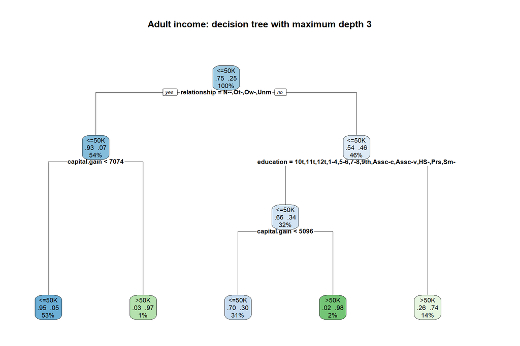

```r
rpart.plot(tree_model, main = "Adult income: decision tree with maximum depth 3",
           extra = 104, fallen.leaves = TRUE, faclen = 3, varlen = 0, cex = .65)
```

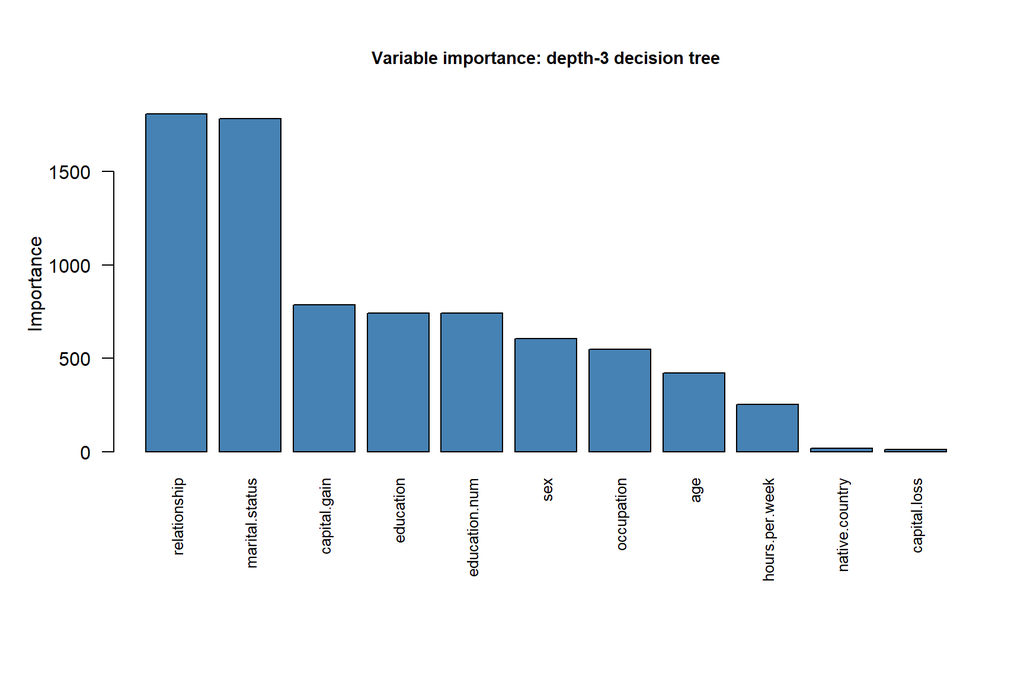

```r
tree_importance <- sort(tree_model$variable.importance, decreasing = TRUE)
par(mar = c(10, 5, 5, 2))
barplot(tree_importance, las = 2, cex.names = .8, col = "steelblue",
        main = "Variable importance: depth-3 decision tree", cex.main = .9,
        ylab = "Importance")
```

Category names in the tree are abbreviated to fit the figure. The tree uses a series of splits to classify income. A larger importance value means a variable contributes more to this tree’s splits; it does not show that the variable causes higher income.

3. Create 3 more trees and compare the testing accuracy of these trees, which tree give the highest testing accuracy.

```r
# A smaller cp permits additional splits in the three deeper trees.
tree_2 <- rpart(target ~ ., data = df_train, method = "class",
               control = rpart.control(maxdepth = 5, cp = .001))
tree_3 <- rpart(target ~ ., data = df_train, method = "class",
               control = rpart.control(maxdepth = 7, cp = .001))
tree_4 <- rpart(target ~ ., data = df_train, method = "class",
               control = rpart.control(maxdepth = 10, cp = .001))

tree_2_cm <- confusionMatrix(predict(tree_2, df_test, type = "class"),
                             df_test$target, positive = ">50K")
tree_3_cm <- confusionMatrix(predict(tree_3, df_test, type = "class"),
                             df_test$target, positive = ">50K")
tree_4_cm <- confusionMatrix(predict(tree_4, df_test, type = "class"),
                             df_test$target, positive = ">50K")

tree_results <- data.frame(
  Model = c("Tree 1", "Tree 2", "Tree 3", "Tree 4"),
  Maximum_depth = c(3, 5, 7, 10),
  cp = c(.01, .001, .001, .001),
  Accuracy = c(tree_cm$overall["Accuracy"], tree_2_cm$overall["Accuracy"],
               tree_3_cm$overall["Accuracy"], tree_4_cm$overall["Accuracy"]),
  row.names = NULL
)
knitr::kable(tree_results, digits = 4)
```

| Model | Maximum_depth | cp | Accuracy |
| --- | --- | --- | --- |
| Tree 1 | 3 | 0.010 | 0.8370 |
| Tree 2 | 5 | 0.001 | 0.8441 |
| Tree 3 | 7 | 0.001 | 0.8471 |
| Tree 4 | 10 | 0.001 | 0.8582 |

```r
best_trees <- tree_results %>% filter(Accuracy == max(Accuracy))
best_trees
```

```
##    Model Maximum_depth    cp  Accuracy
## 1 Tree 4            10 0.001 0.8582325
```

The highest tree testing accuracy is **85.82%**, achieved by **Tree 4**. Maximum depth limits the number of splitting levels. The complexity parameter `cp` controls how much a proposed split must improve the fit; a smaller value permits more splits. The table records both settings.

4. Practice Random Forest. Do the follows:
- Use `randomForest` package, create a random forest of 1000 trees.
- Calculate the accuracy of the model on the testing data.
- Plot the variable importance by the forest

```r
set.seed(421)
forest_model <- randomForest(target ~ ., data = df_train, ntree = 1000)

forest_pred <- predict(forest_model, df_test, type = "class")
forest_cm <- confusionMatrix(data = forest_pred, reference = df_test$target,
                             positive = ">50K")
forest_cm
```

```
## Confusion Matrix and Statistics
##
##           Reference
## Prediction <=50K >50K
##      <=50K  4220  529
##      >50K    310  972
##
##                Accuracy : 0.8609
##                  95% CI : (0.8519, 0.8695)
##     No Information Rate : 0.7511
##     P-Value [Acc > NIR] : < 2.2e-16
##
##                   Kappa : 0.6088
##
##  Mcnemar's Test P-Value : 5.224e-14
##
##             Sensitivity : 0.6476
##             Specificity : 0.9316
##          Pos Pred Value : 0.7582
##          Neg Pred Value : 0.8886
##              Prevalence : 0.2489
##          Detection Rate : 0.1612
##    Detection Prevalence : 0.2126
##       Balanced Accuracy : 0.7896
##
##        'Positive' Class : >50K
##
```

```r
forest_cm$overall["Accuracy"]
```

```
##  Accuracy
## 0.8608854
```

The random forest with 1,000 trees has testing accuracy of **86.09%**.

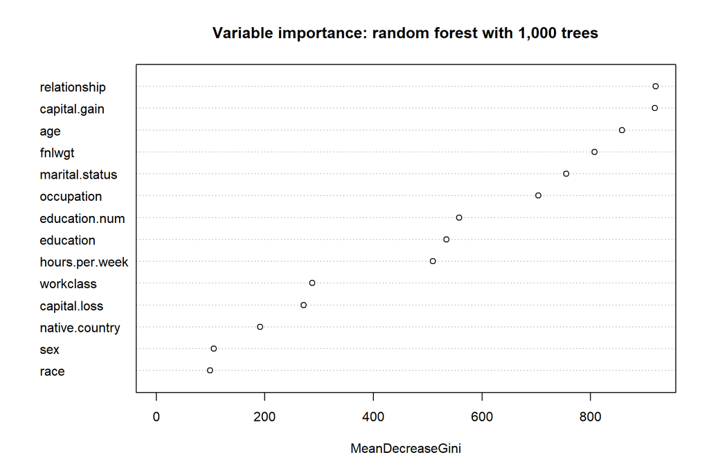

```r
varImpPlot(forest_model, type = 2,
           main = "Variable importance: random forest with 1,000 trees")
```

The forest combines predictions from many trees using a majority vote. The importance plot uses Mean Decrease Gini, which summarizes how much each predictor helps separate classes across the forest’s splits. These scores describe predictive use, not causal effects.

5. Create 3 more forests and compare the testing accuracy of these forests, which forest give the highest testing accuracy.

```r
# Change the number of trees while keeping the other settings the same.
set.seed(421)
forest_2 <- randomForest(target ~ ., data = df_train, ntree = 100)
set.seed(421)
forest_3 <- randomForest(target ~ ., data = df_train, ntree = 500)
set.seed(421)
forest_4 <- randomForest(target ~ ., data = df_train, ntree = 1500)

forest_2_cm <- confusionMatrix(predict(forest_2, df_test, type = "class"),
                               df_test$target, positive = ">50K")
forest_3_cm <- confusionMatrix(predict(forest_3, df_test, type = "class"),
                               df_test$target, positive = ">50K")
forest_4_cm <- confusionMatrix(predict(forest_4, df_test, type = "class"),
                               df_test$target, positive = ">50K")

forest_results <- data.frame(
  Model = c("Forest 1", "Forest 2", "Forest 3", "Forest 4"),
  Trees = c(1000, 100, 500, 1500),
  Accuracy = c(forest_cm$overall["Accuracy"], forest_2_cm$overall["Accuracy"],
               forest_3_cm$overall["Accuracy"], forest_4_cm$overall["Accuracy"]),
  row.names = NULL
)
knitr::kable(forest_results, digits = 4)
```

| Model | Trees | Accuracy |
| --- | --- | --- |
| Forest 1 | 1000 | 0.8609 |
| Forest 2 | 100 | 0.8599 |
| Forest 3 | 500 | 0.8604 |
| Forest 4 | 1500 | 0.8609 |

```r
best_forests <- forest_results %>% filter(Accuracy == max(Accuracy))
best_forests
```

```
##      Model Trees  Accuracy
## 1 Forest 1  1000 0.8608854
## 2 Forest 4  1500 0.8608854
```

The highest forest testing accuracy is **86.09%**, achieved by **Forest 1 (1000 trees), Forest 4 (1500 trees)**. Adding more trees does not guarantee a higher score on this particular test set.

6. What is the best model (in term of testing accuracy) among all models (including trees and forests) you have trained?

```r
all_results <- bind_rows(
  tree_results %>% select(Model, Accuracy),
  forest_results %>% select(Model, Accuracy)
) %>% arrange(desc(Accuracy))

knitr::kable(all_results, digits = 4)
```

| Model | Accuracy |
| --- | --- |
| Forest 1 | 0.8609 |
| Forest 4 | 0.8609 |
| Forest 3 | 0.8604 |
| Forest 2 | 0.8599 |
| Tree 4 | 0.8582 |
| Tree 3 | 0.8471 |
| Tree 2 | 0.8441 |
| Tree 1 | 0.8370 |

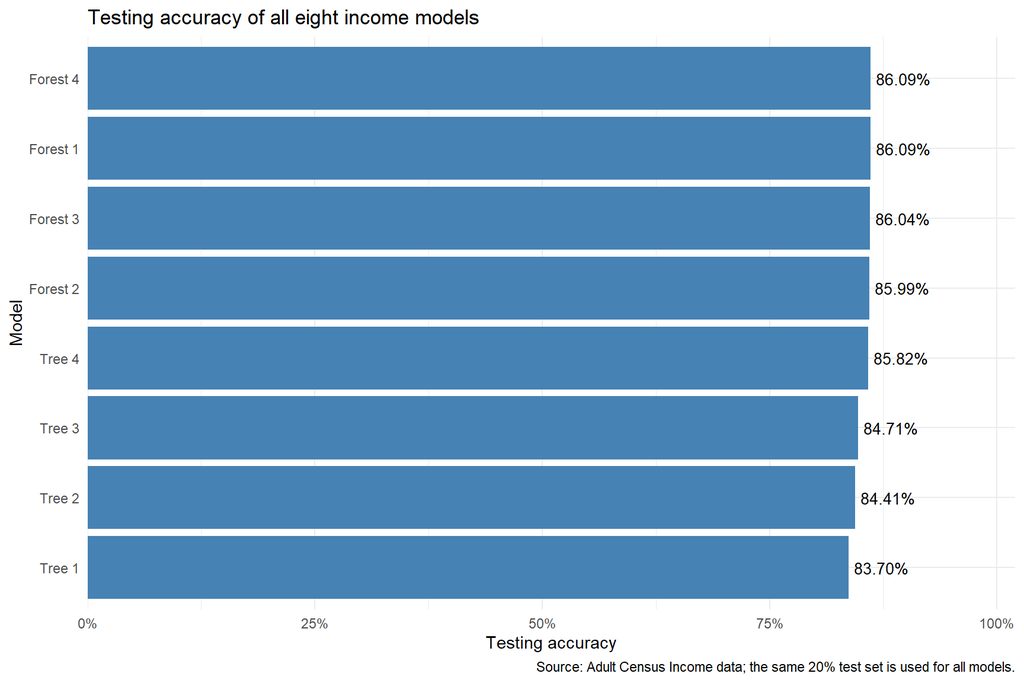

```r
best_models <- all_results %>% filter(Accuracy == max(Accuracy))

ggplot(all_results, aes(x = reorder(Model, Accuracy), y = Accuracy)) +
  geom_col(fill = "steelblue") +
  geom_text(aes(label = scales::percent(Accuracy, accuracy = .01)),
            hjust = -.1, size = 3.5) +
  coord_flip() +
  scale_y_continuous(labels = scales::percent,
                     limits = c(0, 1), expand = expansion(mult = c(0, .02))) +
  labs(title = "Testing accuracy of all eight income models",
       x = "Model", y = "Testing accuracy",
       caption = "Source: Adult Census Income data; the same 20% test set is used for all models.") +
  theme_minimal()
```

The best model on this testing split is **Forest 1, Forest 4**, with accuracy of **86.09%**. For context, always predicting the majority income class on the test set would have accuracy of **75.11%**.

This assignment asks us to compare models by testing accuracy. Because this same test set also helps choose the winning model, its winning score may be optimistic as an estimate of future performance. A separate final holdout set would be useful for evaluating a model selected this way.